## Tutorial for Data Science

### Table of Contents

I. Introduction

2. Data
1. Data Preparation
2. Data Manipulation
3. Analysis
1. Statistical
2. Visual
4. Regression

V. Conclusion

## I. Introduction

Hello! Welcome to the Data Science Tutorial! We will teach you how to work with R and how to work with data sets! The data set we are working with is coronavirus cases around the world, as this is the most current problem we have to face. As a result, understanding the data gathered from cases around the globe can slow down and possibly prevent the spread of this virus.

We will show you how to turn a data set(which can be represented by an Excel Spreadsheet) into a spreadsheet with only the data we want, how to add to the data, how to create graphs, and how to make inferences and future predictions based off the graphs. These predictions could help solve this COVID-19 crisis as we could figure out through predictions from models where the problem is most persistent, where it will be the most persistent in the future, and who is most likely to get it.

## 1. Data Preparation

This segment of code initializes the data and allows us to work with data sets. This image below is what the current state of retrovirus is at. This can all be created through the use of data.

[figure not shown]

```r
knitr::opts_chunk$set(echo = TRUE)
knitr::include_graphics("covid19.jpg")
```

As a start, we have to load packages into R Studio, which allows us to access and use many of R Studio’s functionalities. This also allows us to exclude unnecessary packages which could cause conflicting attributes and data representations. For example, the tidyverse package allows us to create graphs/charts based on the provided data set and modify them as well. Tidyverse is a package which contains many other packages for the most commonly used functionalities in R Studio.

```r
library(tidyverse)
library(askpass)
library(datasets)
library(lubridate)
library(stringr)
library(leaflet)
```

```r
data <- read_csv("data/final_covid_data.csv")
data
```

```
## # A tibble: 13,174 x 33
##       ID age   sex   city  province country `wuhan(0)_not_w… latitude longitude
##    <dbl> <chr> <chr> <chr> <chr>    <chr>              <dbl> <chr>    <chr>
##  1     1 30    male  Chao… Anhui    China                  1 31.64696 117.7166
##  2     2 47    male  Baoh… Anhui    China                  1 31.77863 117.3319
##  3     3 49    male  High… Anhui    China                  1 31.8283… 117.2248…
##  4     4 47    fema… High… Anhui    China                  1 31.8283… 117.2248…
##  5     5 50    fema… Feid… Anhui    China                  1 32.00123 117.5681
##  6     6 N/A   N/A   Lu'a… Anhui    China                  1 31.75941 116.3151
##  7     7 42    fema… Fuya… Anhui    China                  1 32.9188  115.7036
##  8     8 <NA>  fema… Huai… Anhui    China                  1 33.72722 116.7424
##  9     9 59    fema… Huai… Anhui    China                  1 32.75738 116.734
## 10    10 30    male  Hefe… Anhui    China                  1 31.79444 117.3428
## # … with 13,164 more rows, and 24 more variables: geo_resolution <chr>,
## #   date_onset_symptoms <chr>, date_admission_hospital <chr>,
## #   date_confirmation <chr>, symptoms <chr>, lives_in_Wuhan <chr>,
## #   travel_history_dates <chr>, travel_history_location <chr>,
## #   reported_market_exposure <chr>, additional_information <chr>,
## #   chronic_disease_binary <chr>, chronic_disease <chr>, source <chr>,
## #   sequence_available <chr>, outcome <chr>, date_death_or_discharge <chr>,
## #   notes_for_discussion <chr>, location <chr>, admin3 <chr>, admin2 <chr>,
## #   admin1 <chr>, country_new <chr>, admin_id <chr>,
## #   data_moderator_initials <lgl>
```

This variable called “simple_data” is our original data set with one modification. There are a large number of columns, many of which have empty values or are irrelevant in gathering useful data, so we want to keep all the relevant columns. In this case, we are saving the rows for dates reported for coronavirus, the country that reported the case, the gender of the person with the virus, their age, and the geographical coordinates of their location when the virus was discovered in them. This cleans up our data set as we have only what we need.

```r
simple_data <- data %>%
  select("date_confirmation", "country", "sex", "age", "latitude", "longitude")
simple_data
```

```
## # A tibble: 13,174 x 6
##    date_confirmation country sex    age   latitude  longitude
##    <chr>             <chr>   <chr>  <chr> <chr>     <chr>
##  1 22/01/2020        China   male   30    31.64696  117.7166
##  2 23/01/2020        China   male   47    31.77863  117.3319
##  3 23/01/2020        China   male   49    31.828313 117.224844
##  4 23/01/2020        China   female 47    31.828313 117.224844
##  5 23/01/2020        China   female 50    32.00123  117.5681
##  6 24/01/2020        China   N/A    N/A   31.75941  116.3151
##  7 22/01/2020        China   female 42    32.9188   115.7036
##  8 25/01/2020        China   female <NA>  33.72722  116.7424
##  9 26/01/2020        China   female 59    32.75738  116.734
## 10 23/01/2020        China   male   30    31.79444  117.3428
## # … with 13,164 more rows
```

This next chunk is working with making it much easier to work with our reporting date column. There is no real numerical order as to sorting by date as we have to consider the year, the month, and the day. At the same time the format for a date can be day-month-year, month-day-year, year-month-day. Also, the “-” could be a “/”. To account for this complication, we use the lubridate package which formats our date into the proper format so we can do operations on the various dates. We add this new column and set its title to “date”. We can then discard the original reporting date_confirmation as we have a newly formatted, usable date column.

```r
simple_data <- simple_data %>%
  mutate(date=dmy(simple_data$`date_confirmation`), age=as.integer(age))%>%
  mutate(sex=na_if(sex , "N/A")) %>%
  select(-"date_confirmation")
simple_data
```

```
## # A tibble: 13,174 x 6
##    country sex      age latitude  longitude  date
##    <chr>   <chr>  <int> <chr>     <chr>      <date>
##  1 China   male      30 31.64696  117.7166   2020-01-22
##  2 China   male      47 31.77863  117.3319   2020-01-23
##  3 China   male      49 31.828313 117.224844 2020-01-23
##  4 China   female    47 31.828313 117.224844 2020-01-23
##  5 China   female    50 32.00123  117.5681   2020-01-23
##  6 China   <NA>      NA 31.75941  116.3151   2020-01-24
##  7 China   female    42 32.9188   115.7036   2020-01-22
##  8 China   female    NA 33.72722  116.7424   2020-01-25
##  9 China   female    59 32.75738  116.734    2020-01-26
## 10 China   male      30 31.79444  117.3428   2020-01-23
## # … with 13,164 more rows
```

## 2. Data Manipulation

```r
new_simple_data <- simple_data %>%  mutate(age = as.numeric(age))  %>%
 replace_na(list(latitude=as.integer(mean(.$latitude, na.rm=TRUE)))) %>% mutate(latitude = as.numeric(latitude))%>%
  replace_na(list(longitude=as.integer(mean(.$longitude, na.rm=TRUE)))) %>% mutate(longitude = as.numeric(longitude))%>%
  replace_na(list(age=as.integer(mean(.$age, na.rm=TRUE))))
new_simple_data
```

```
## # A tibble: 13,174 x 6
##    country sex      age latitude longitude date
##    <chr>   <chr>  <dbl>    <dbl>     <dbl> <date>
##  1 China   male      30     31.6      118. 2020-01-22
##  2 China   male      47     31.8      117. 2020-01-23
##  3 China   male      49     31.8      117. 2020-01-23
##  4 China   female    47     31.8      117. 2020-01-23
##  5 China   female    50     32.0      118. 2020-01-23
##  6 China   <NA>      43     31.8      116. 2020-01-24
##  7 China   female    42     32.9      116. 2020-01-22
##  8 China   female    43     33.7      117. 2020-01-25
##  9 China   female    59     32.8      117. 2020-01-26
## 10 China   male      30     31.8      117. 2020-01-23
## # … with 13,164 more rows
```

## 3. Data Analysis and Visualization

Part 1 : The top 10 countries with the highest number of corona cases. The way we can produce the output is to use a count function

```r
simple_data2 <- new_simple_data %>%
  select(date, country) %>%
  group_by(country) %>%
  count(country) %>%
  rename(number_of_cases = n) %>%
  arrange(desc(number_of_cases))
simple_data3 <- na.omit(simple_data2)
head(simple_data3, n = 10)
```

```
## # A tibble: 10 x 2
## # Groups:   country [10]
##    country     number_of_cases
##    <chr>                 <int>
##  1 China                 10446
##  2 South Korea             938
##  3 Japan                   731
##  4 Italy                   588
##  5 Singapore                91
##  6 Thailand                 40
##  7 Iran                     28
##  8 Kuwait                   26
##  9 Bahrain                  20
## 10 Germany                  20
```

From this data, we can see that China has the most corona cases . Although currently, the USA leads in corona cases, this is reflective of the dataset which we used.

Now we will use a bar graph to visualize the relationship between a continuous variable (number of cases) to a categorical attribute such as a country. To do the plotting, we use ggplot.

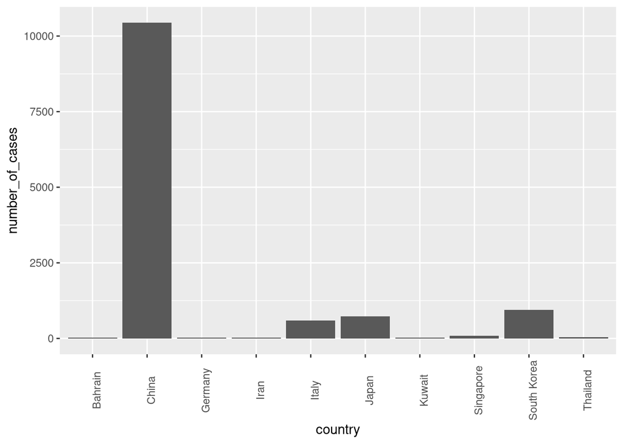

```r
simple_data2 %>%
  filter(country %in% c("China", "South Korea", "Japan", "Italy", "Singapore", "Thailand", "Iran", "Kuwait", "Bahrain", "Turkey", "Germany")) %>%
  ggplot(mapping=aes(x=country, y=number_of_cases)) +
    geom_bar(stat="identity") + theme(axis.text.x =   element_text(angle = 90))
```

Part 2 : Progression of Corona over time from late January to late February.

We will see the progression of the corona virus pandemic in these countries every day and over time. First we need to filter the data set so it only contains the 3 countries that we need to analyze. Since this virus spreads really fast, we will use the greatest number of attacks on one specific day. Since a month is a short time, we have to focus on days to really see the impact of corona.

```r
library(ggplot2)
library(tidyverse)
library(lubridate)
library(readr)
library(dplyr)

simple_data3 <- simple_data %>%
  filter(country== "China" | country == "South Korea" | country == "Japan") %>%
  group_by(date, country) %>%
  count(date, country) %>%
  rename(number_of_cases = n) %>%
  arrange(desc(number_of_cases))
head(simple_data3)
```

```
## # A tibble: 6 x 3
## # Groups:   date, country [6]
##   date       country number_of_cases
##   <date>     <chr>             <int>
## 1 2020-01-29 China              1073
## 2 2020-02-03 China               854
## 3 2020-01-31 China               783
## 4 2020-02-05 China               775
## 5 2020-02-04 China               729
## 6 2020-01-27 China               720
```

After getting the data set, we utilize a line graph/chart to visualize this growth over a one month duration.

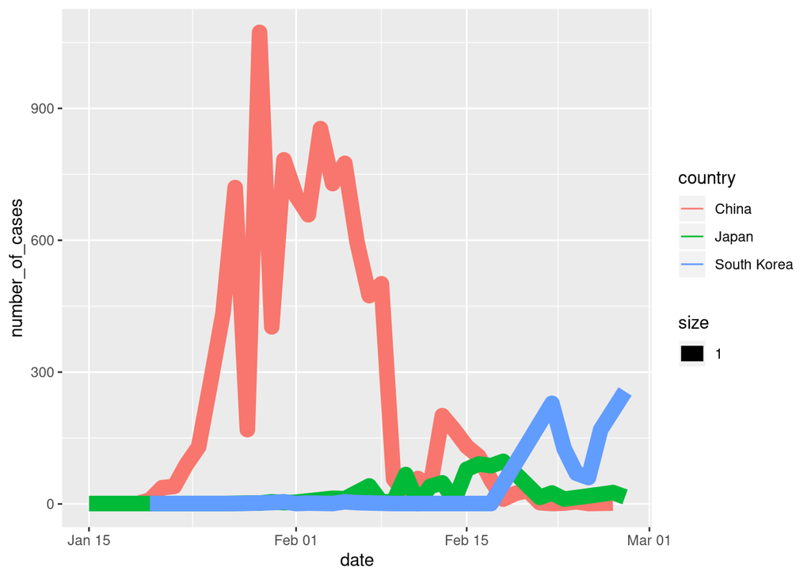

```r
library(ggplot2)
library(tidyverse)
library(lubridate)
library(readr)
library(dplyr)

simple_data3 %>%
 filter(country %in% c("China", "South Korea", "Japan")) %>%
  ggplot(mapping = aes(x=date, y=number_of_cases, size=1)) +
  geom_line(aes(color=country))
```

Through this line graph/chart, we can see that as the cases in china slowly went down, the cases in other countries started to go up. This relationship is pretty interesting because from a holistic standpoint, corona cases for all the countries should spike. In this graph, we can also see that China was hit the hardest in late January and early February with a huge spike near Feb 1.

Part 3: The most vulnerable age group of corona virus.

We have the data of corona virus cases, but now we can count the number of cases based on an age group.

```r
library(ggplot2)
library(tidyverse)
library(lubridate)
library(readr)
library(dplyr)


simple_data <- simple_data %>% mutate(age=na_if(age,"N/A"))
simple_data4 <- simple_data %>%
group_by(age) %>%
count(age) %>%
rename(number_of_cases = n) %>%
arrange(desc(number_of_cases))
simple_data5 <- na.omit(simple_data4)
head(simple_data5)
```

```
## # A tibble: 6 x 2
## # Groups:   age [6]
##     age number_of_cases
##   <int>           <int>
## 1    33              29
## 2    50              29
## 3    49              27
## 4    30              26
## 5    35              26
## 6    42              24
```

To visualize this, we will use the same visualization method we used for the top 10 countries with the highest number of COVID-19 cases between January and February.

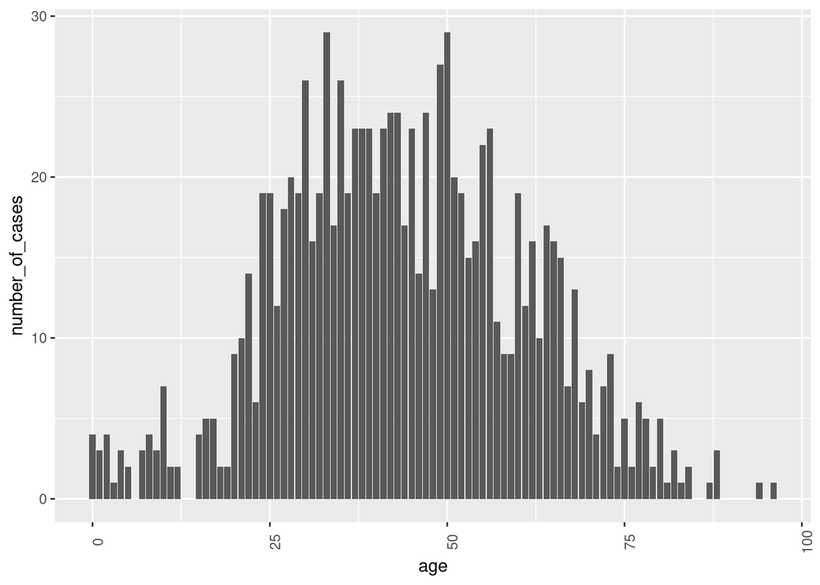

```r
library(ggplot2)
library(tidyverse)
library(lubridate)
library(readr)
library(dplyr)

simple_data5 %>%
  ggplot(mapping=aes(x=age, y=number_of_cases)) +
    geom_bar(stat="identity") + theme(axis.text.x = element_text(angle = 90))
```

Part 4. Gender of people affected by coronavirus in China

This code is using the leaflet package and loads a map of china.

```r
library(leaflet)

china_map <- leaflet(new_simple_data) %>%
  addTiles() %>%
  setView(lat=35.8617, lng=104.1954, zoom=11)
china_map
```

[interactive chart not shown]

This following code will plot the genders on the map.

```r
library(tidyverse)



leaflet(new_simple_data) %>% addTiles() %>%
  addCircleMarkers(
    radius =~ifelse(sex == "F", 6, 10),
    color = c("Red", "Blue"),
    stroke = FALSE, fillOpacity = 0.5
  )
```

```
## Assuming "longitude" and "latitude" are longitude and latitude, respectively
```

[interactive chart not shown]

## Regression

Now that we have done analysis on the COVID-19 data, we want to see if we can use this data in order to make predictions about the future. Given the severity of the coronavirus pandemic, it is important to be able to forecast how many new infections we can expect in order to take the necessary precautions to the slow the spread of the virus.

One way we can predict the new cases is to use a method called linear regression. Essentially, we use already collected data to create linear function that takes in a set of attributes related to coronavirus and spits out the predicted number of new cases.

For our first linear model, we will try to see if we can predict the total number of global cases of coronavirus. To do this, first we need to slightly restructure the data. The simple_data dataset has an attribute for each individual case, so we can total new cases for a given time if we group them by date reported.

```r
global_case_data <- simple_data %>%
  group_by(date) %>%
  summarize(new_cases=n()) %>%
  mutate(new_cases=cumsum(new_cases))
```

Now that the data is in the proper format, we can create a simple linear regression model.

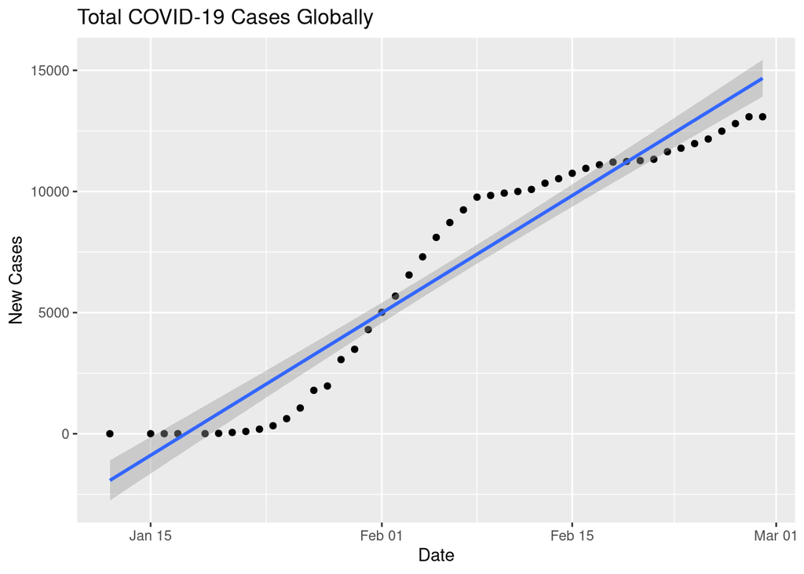

```r
global_case_data %>% ggplot(aes(x=date, y=new_cases)) +
  geom_point() +
  geom_smooth(method=lm) +
  labs(title="Total COVID-19 Cases Globally ", x="Date", y="New Cases")
```

We can measure how useful this linear model is using hypothesis testing. If the p-value for an attribute is less than a threshold of 0.05, the null hypothesis is rejected. This also means that the the relationship between the attribute and the result is statistically significant.

```r
regression_model <- lm(new_cases~date, data=global_case_data)
broom::tidy(regression_model)
```

```
## # A tibble: 2 x 5
##   term         estimate std.error statistic  p.value
##   <chr>           <dbl>     <dbl>     <dbl>    <dbl>
## 1 (Intercept) -6320982.  261988.      -24.1 5.28e-27
## 2 date             346.      14.3      24.2 5.05e-27
```

This method of predicting global coronavirus cases is useful, but what if we want to make more specific predictions? For instance, can we predict the number of COVID-19 cases at a specific time and location? Our linear regression model can be extended for to make predictions using more than one attribute.

```r
location_case_data <- simple_data %>%
  group_by(country, date) %>%
  summarize(new_cases=n()) %>%
  mutate(new_cases=cumsum(new_cases))

ry <- lm(new_cases~date+country, data=location_case_data)
broom::tidy(ry)
```

```
## # A tibble: 52 x 5
##    term               estimate std.error statistic  p.value
##    <chr>                 <dbl>     <dbl>     <dbl>    <dbl>
##  1 (Intercept)      -1278996.  166790.     -7.67   4.43e-13
##  2 date                   69.8      9.11    7.67   4.42e-13
##  3 countryAlgeria        -69.8   2087.     -0.0335 9.73e- 1
##  4 countryAustralia     1659.    1580.      1.05   2.95e- 1
##  5 countryAustria        -68.8   2087.     -0.0330 9.74e- 1
##  6 countryBahrain        -60.5   1704.     -0.0355 9.72e- 1
##  7 countryBelgium       1397.    2095.      0.667  5.06e- 1
##  8 countryBrazil         -69.8   2087.     -0.0335 9.73e- 1
##  9 countryCambodia      1955.    2102.      0.930  3.53e- 1
## 10 countryCanada        1156.    1572.      0.735  4.63e- 1
## # … with 42 more rows
```

This regression model takes into account the current date and the reported location of coronavirus cases. In many cases, the p-values for the case-location relationships are > 0.05 which means they are not statistically significant relations. The only location attribute that is within the p-value threshold is China. This indicates that we can only make statistically significant predictions about the number of expected coronavirus cases for the location: China. The likely reason that none of the other locations have statistically significant relationships is a lack of collected data in this dataset. If other more case data was collected for other countries, it would be much easier to form accurate predictions for those locations.

Another attribute that may be of interest to measure with linear regression is age. This would allow us to predict the number of cases over time among different age groups.

```r
age_case_data <- simple_data %>%
  group_by(date, age) %>%
  summarize(new_cases=n()) %>%
  mutate(new_cases=cumsum(new_cases))

ry <- lm(new_cases~date+age, data=age_case_data)
broom::tidy(ry)
```

```
## # A tibble: 3 x 5
##   term        estimate std.error statistic   p.value
##   <chr>          <dbl>     <dbl>     <dbl>     <dbl>
## 1 (Intercept) 7241.     675.          10.7 4.88e- 25
## 2 date          -0.396    0.0369     -10.7 4.47e- 25
## 3 age            0.561    0.0203      27.6 7.97e-116
```

For this model, the p-values for both date and age are < 0.05 so they both are statistically significant attributes.

Ideally, for the most accurate predictions, we would create a linear regression model that takes all of these attributes into account.

```r
age_loc_case_data <- simple_data %>%
  group_by(country, date, age) %>%
  summarize(new_cases=n())

ry <- lm(new_cases~date+country+age, data=age_loc_case_data)
broom::tidy(ry)
```

```
## # A tibble: 36 x 5
##    term             estimate std.error statistic p.value
##    <chr>               <dbl>     <dbl>     <dbl>   <dbl>
##  1 (Intercept)      72.2      43.5       1.66     0.0974
##  2 date             -0.00388   0.00237  -1.64     0.102
##  3 countryAustralia  0.00674   0.542     0.0124   0.990
##  4 countryBrazil     0.0336    0.728     0.0462   0.963
##  5 countryCambodia  -0.0802    0.731    -0.110    0.913
##  6 countryCanada    -0.0925    0.731    -0.127    0.899
##  7 countryChina      0.238     0.518     0.460    0.646
##  8 countryCroatia   -0.00560   0.630    -0.00889  0.993
##  9 countryEstonia    0.00662   0.727     0.00911  0.993
## 10 countryFinland   -0.104     0.730    -0.143    0.886
## # … with 26 more rows
```

Unfortunately, this causes the p-values for all attributes to be greater than the 0.05 threshold. So this regression model is not statistically significant.

For these linear regression models, we can get pretty good results when predicting global COVID-19 cases. However, in order to get better predictions using more attributes, we would need to collect more data.

## Conclusion

In summary, through our tutorial, you have learned how to:

-Load a dataset into RStudio

-Add the needed packages/libraries to work with the datasets

-Clean the dataset to show only what we want to see

-Tidy the datasets by formatting our columns and converting their types into what we want

-Analyized data and used different visualization techniques to learn about the coronavirus

-Used linear regression to make predictions about COVID-19 cases in the future

Dataset used: https://www.kaggle.com/sudalairajkumar/novel-corona-virus-2019-dataset